# Puppy Extreme Brachycephalic Breeds Analysis

Tom Kremer

Last Updated: 2026-01-04

### Preprocessing Notes

1. This page shows the results for all survey questions (since the questions in the list for breed analysis cover almost all of them) split by the “Extreme Brachycephalic” breeds and all others. This is after applying the renaming of breeds based on the provided lists, ending with a total of 201 puppies in the “Extreme Brachycephalic” group compared to 3801 others.

## Introductory Questions (All Respondents)

## S5

**S5: What is your age, in years?**

4002 non-empty/NA responses out of 4002 possible responses ( 100 %)

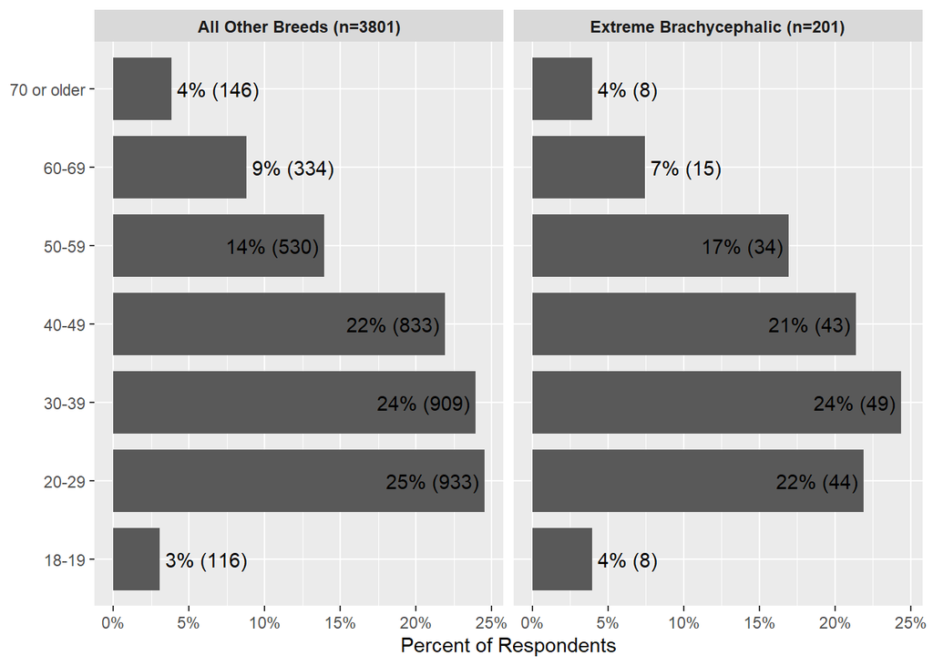

## Q1

**Q1: How old is your puppy now?**

4002 non-empty/NA responses out of 4002 possible responses ( 100 %)

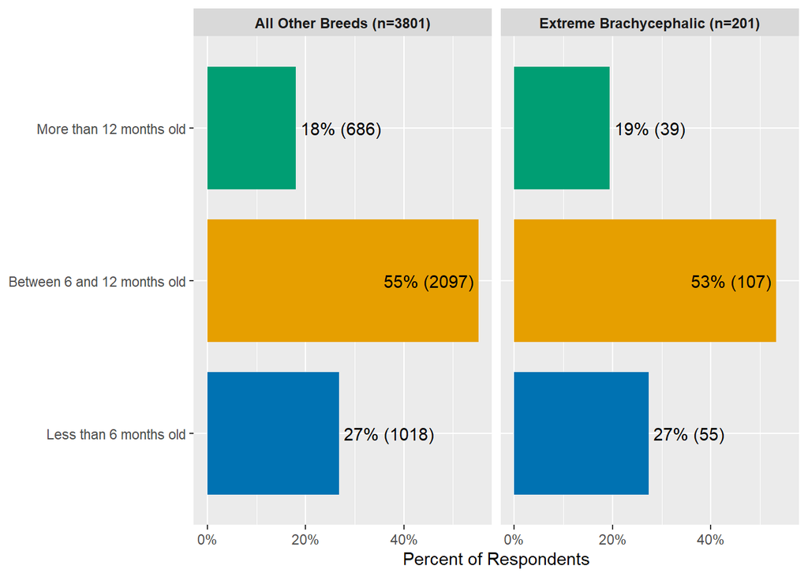

## Q2

**Q2: Are you the puppy’s first owner (besides the breeder, shop, rescue, or shelter where you got your puppy, if applicable)?**

4002 non-empty/NA responses out of 4002 possible responses ( 100 %)

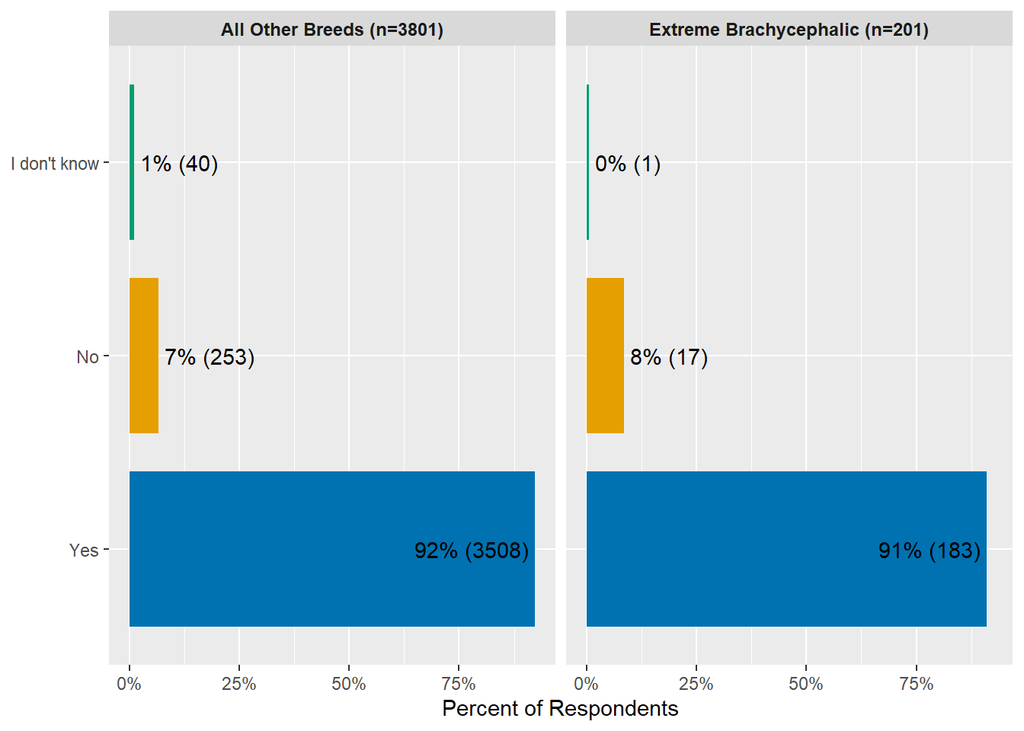

## Q3

**Q3: What is your puppy’s expected size when fully grown?**

4002 non-empty/NA responses out of 4002 possible responses ( 100 %)

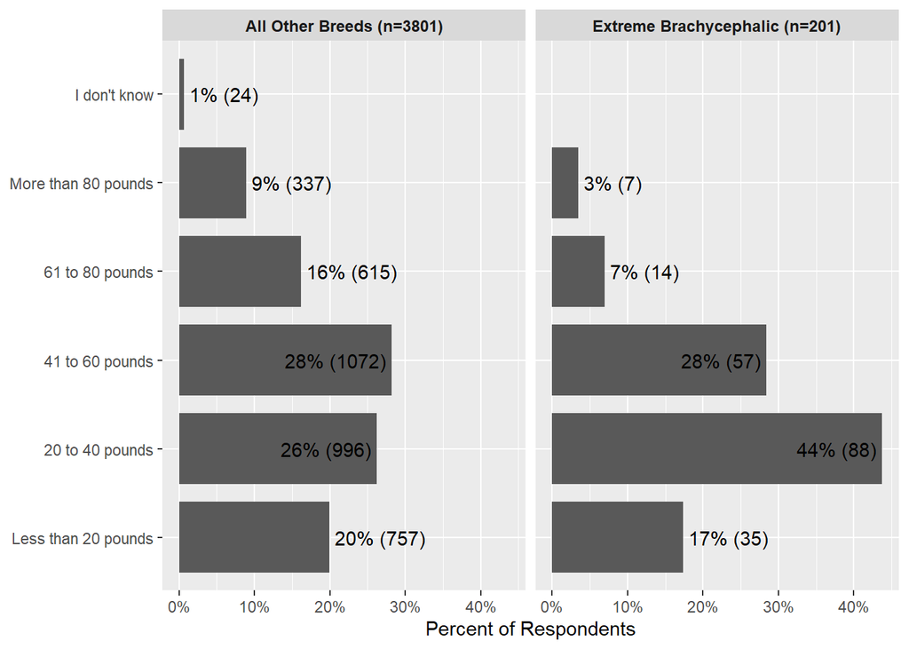

## Q5

**What information do you have on your puppy’s breed?**

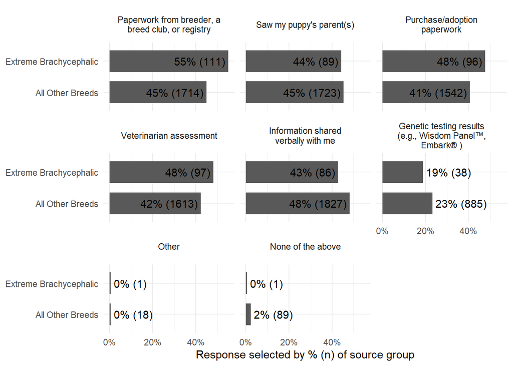

## Q4NEW_new (…)

**Q4: What best describes your puppy’s breed(s)?**

4002 non-empty/NA responses out of 4002 possible responses ( 100 %)

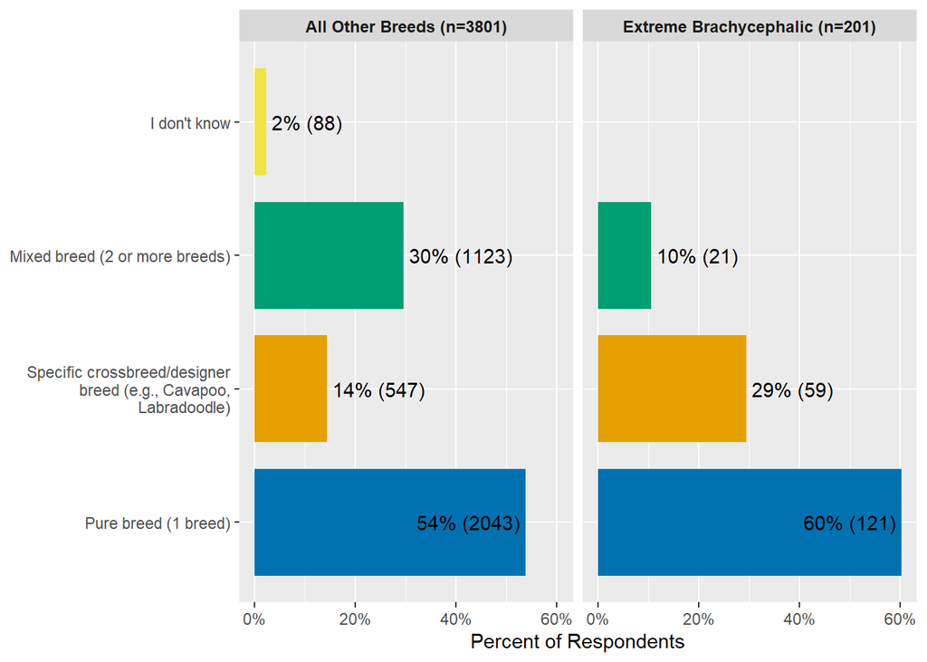

### > Q7

**Breed If answered pure breed**

Showing data for Typology breeds only

| Response | Count | Percent |
| --- | --- | --- |
| French Bulldog | 54 | 45% |
| Pug | 27 | 22% |
| English Bulldog | 24 | 20% |
| Boston Terrier | 15 | 12% |
| Olde English Bulldogge | 1 | 1% |

### > Q8

**Breed if answered specific crossbreed/designer**

Showing data for Typology breeds only

| Response | Count | Percent |
| --- | --- | --- |
| American Boston Bull Terrier (American Pitbull Terrier / Boston Terrier) | 28 | 47% |
| Frenchie Pug (French Bulldog / Pug) | 9 | 15% |
| Puggle (Pug / Beagle) | 9 | 15% |
| Chug (Chihuahua / Pug) | 4 | 7% |
| Olde Pit Bulldogge (Olde English Bulldogge / American Pitbul | 2 | 3% |
| Beabull (Beagle / English Bulldog) | 2 | 3% |
| Bulldogge (English Bulldog / Olde English Bulldogge) | 2 | 3% |
| English De Bordeaux (English Bulldog / Dogue De Bordeaux) | 1 | 2% |
| Bassugg (Basset / Pug) | 1 | 2% |
| Bullador (Bulldog / Labrador) | 1 | 2% |

### > Q9 (…)

**Breed if answered mixed breed**

Showing data for Typology breeds only

| Response | Count | Percent |
| --- | --- | --- |
| Pug | 11 | 52% |
| Boston Terrier | 5 | 24% |
| French Bulldog | 3 | 14% |
| English Bulldog | 2 | 10% |

#### >> Q10

**Q10: Would you like to add a second breed for your puppy?**

1144 non-empty/NA responses out of 1144 possible responses ( 100 %)

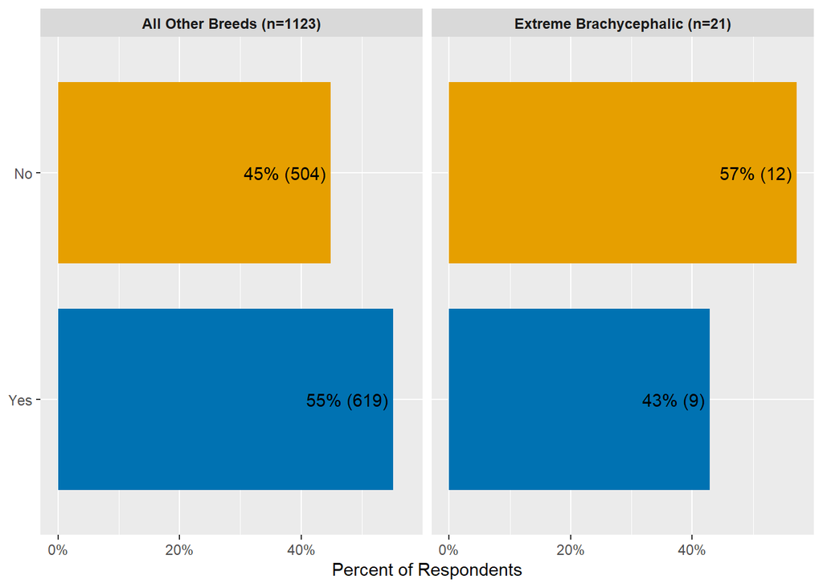

#### >> Q11

**Q11: Text - What is your puppy’s secondary breed? Please type the name in the text box below. It is okay if you are not certain of the breed; please provide your best guess. Select “I don’t know” only if you have no information on the breed.**

Showing data for Typology breeds only

| Response | Count | Percent |
| --- | --- | --- |
| Beagle | 2 | 22% |
| Chihuahua | 2 | 22% |
| Pit Bull | 1 | 11% |
| French Bulldog | 1 | 11% |
| Alaskan Malamute | 1 | 11% |
| Cocker Spaniel | 1 | 11% |
| Rat Terrier | 1 | 11% |

## Q12 (…)

**Q12: Is your puppy sterilized (spayed or neutered)?**

4002 non-empty/NA responses out of 4002 possible responses ( 100 %)

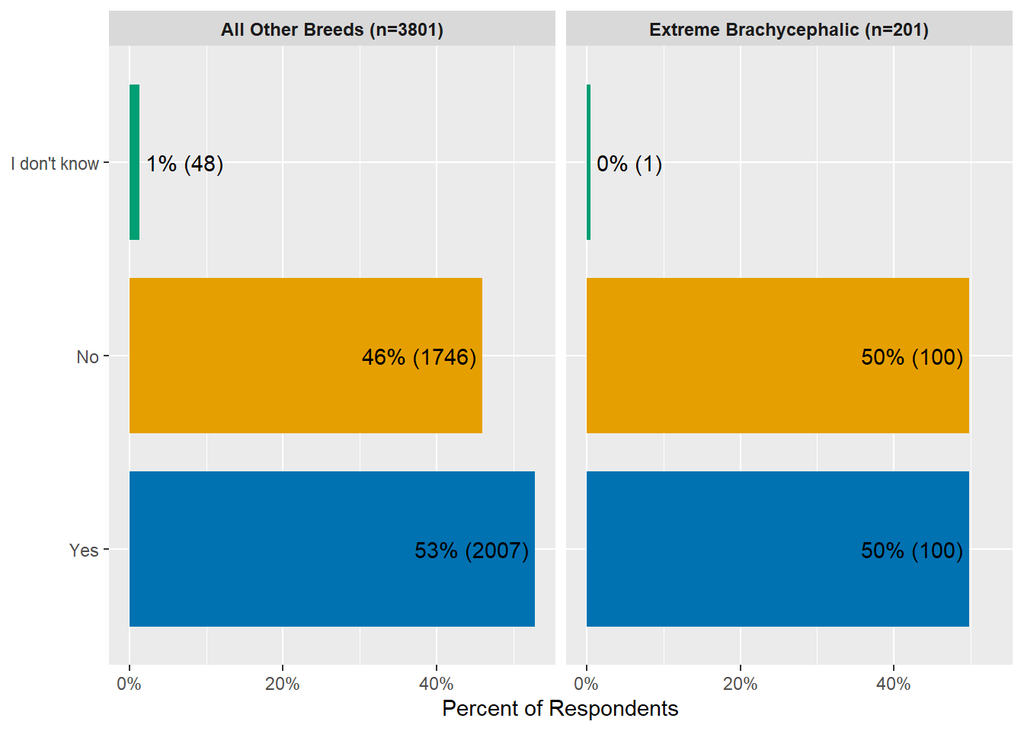

### > Q13 (…)

**Q13: Was your puppy sterilized before you brought them home?**

2107 non-empty/NA responses out of 2107 possible responses ( 100 %)

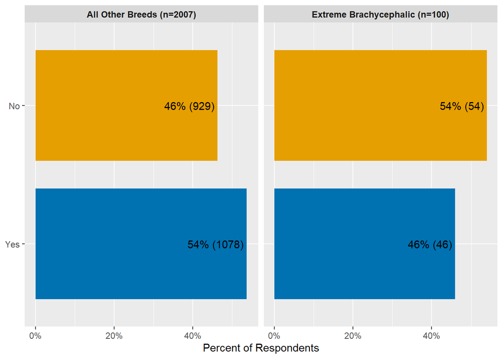

#### >> Q13a

**Q13a: At what age were they sterilized?**

983 non-empty/NA responses out of 983 possible responses ( 100 %)

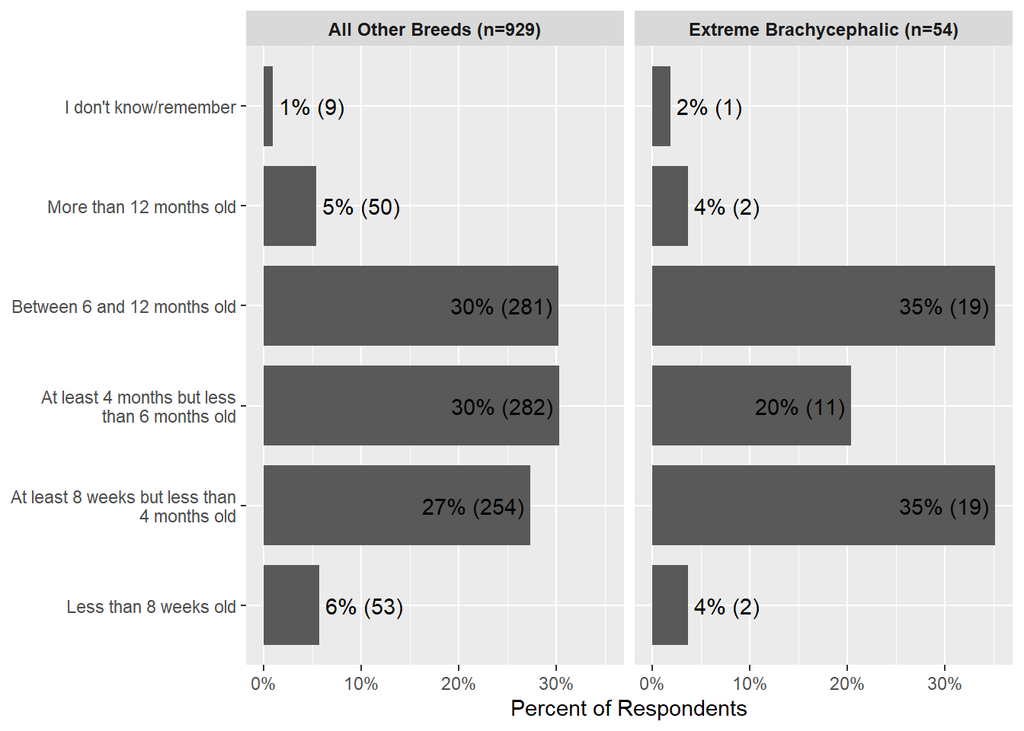

#### >> Q13b

**Q13b: Where did your puppy have their spay/neuter surgery?**

983 non-empty/NA responses out of 983 possible responses ( 100 %)

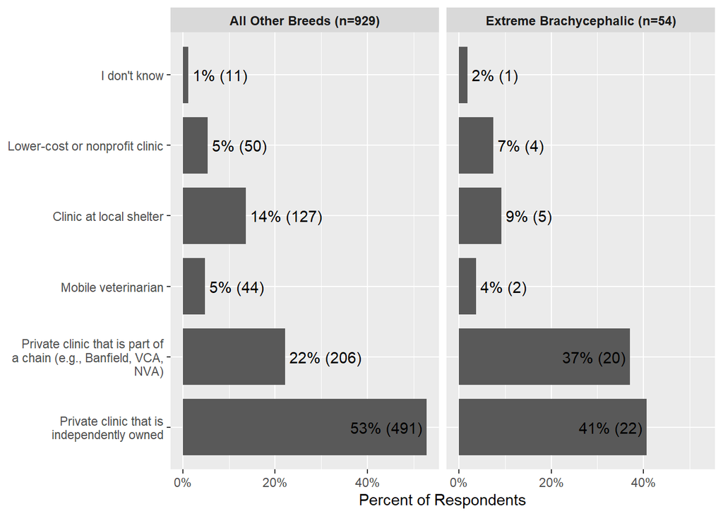

#### >> Q13c (…)

**Q13c: Has your puppy gone to a veterinarian since you got them other than for spay/neuter surgery?**

983 non-empty/NA responses out of 983 possible responses ( 100 %)

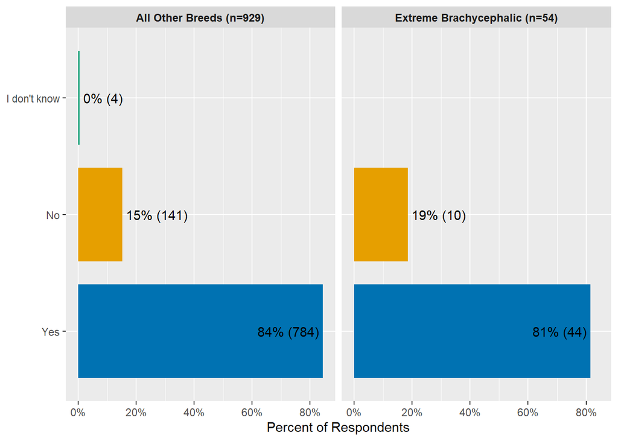

##### >>> Q13d

**Where has your puppy gone for other veterinary care?**

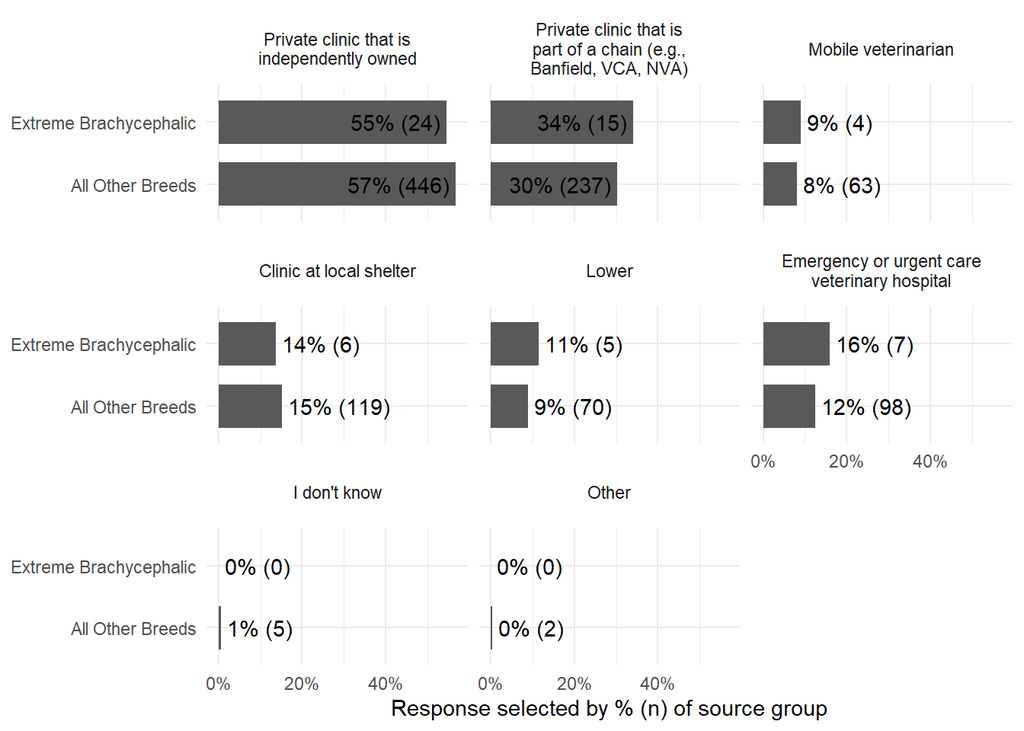

### > Q14

**Q14: Do you plan to breed your puppy in the future?**

1846 non-empty/NA responses out of 1895 possible responses ( 97 %)

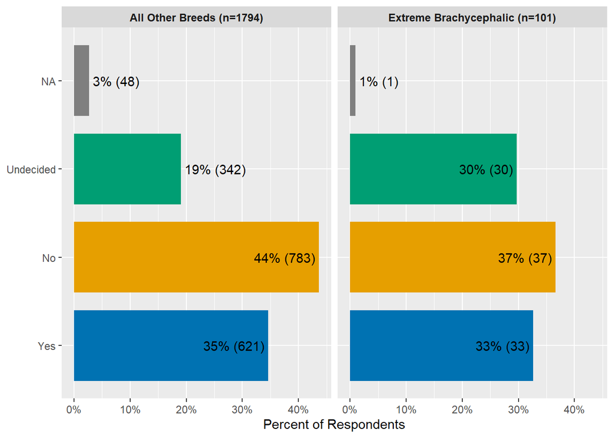

### > Q14a

**Q14a: Do you plan to sterilize your puppy in the future?**

1846 non-empty/NA responses out of 1895 possible responses ( 97 %)

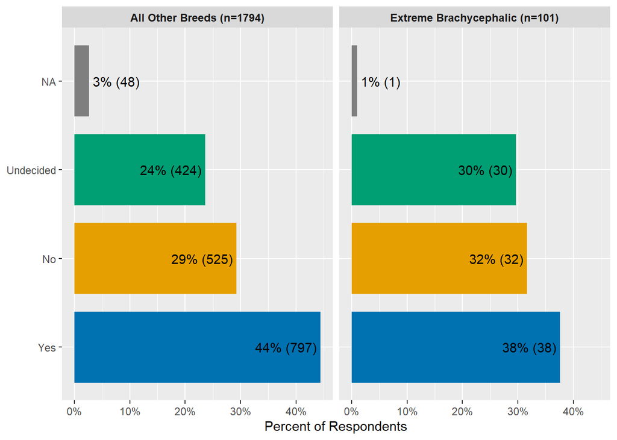

### > Q15

**Q15: Has your puppy gone to a veterinarian since you got them?**

3019 non-empty/NA responses out of 3019 possible responses ( 100 %)

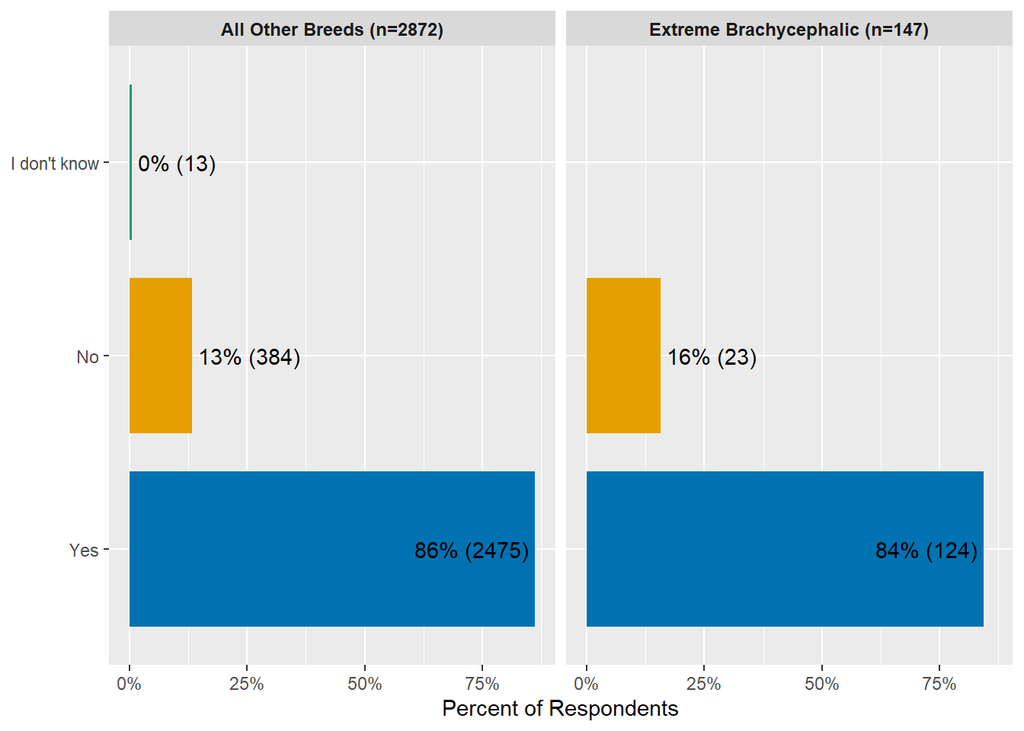

### > Q16

**Where has your puppy gone for veterinary care?**

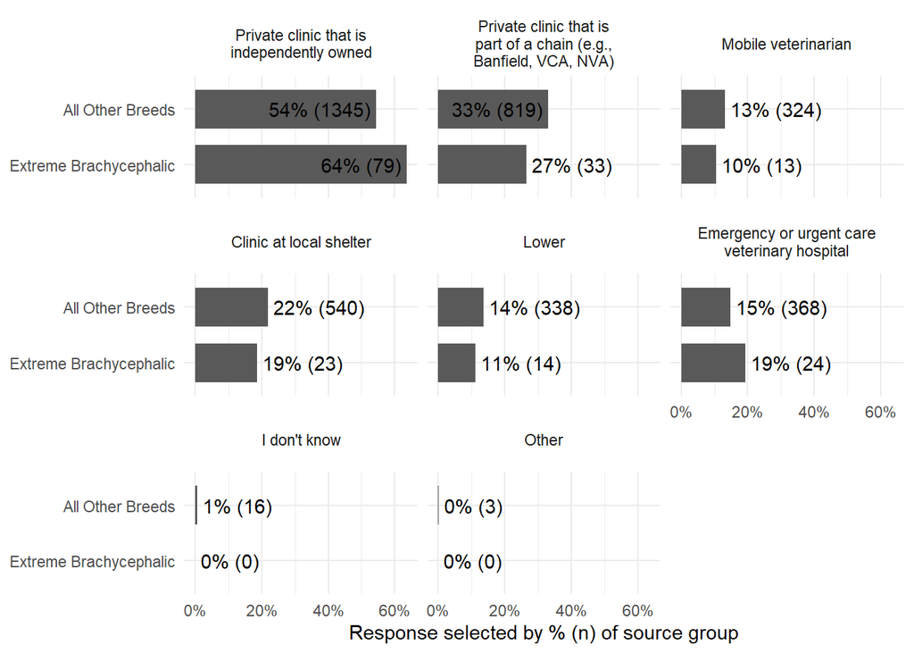

## Q17

**Q17: Before this puppy, were you ever a primary caretaker for a dog as an adult (when you were age 18 or older)?**

4002 non-empty/NA responses out of 4002 possible responses ( 100 %)

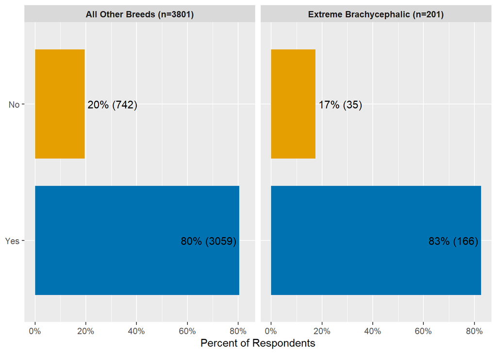

## Group A Only (…)

**Group A Only**

### > Timing and Availability

### > Q18 (…)

**Q18: How much time did you spend searching for a puppy?**

2001 non-empty/NA responses out of 2001 possible responses ( 100 %)

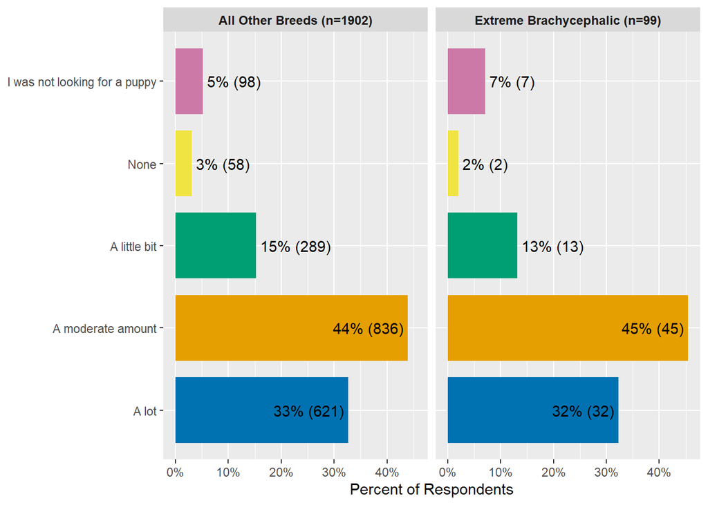

#### >> Q19

**You shared that you didn’t spend time searching for your puppy. Did any of the following apply to you getting your puppy?**

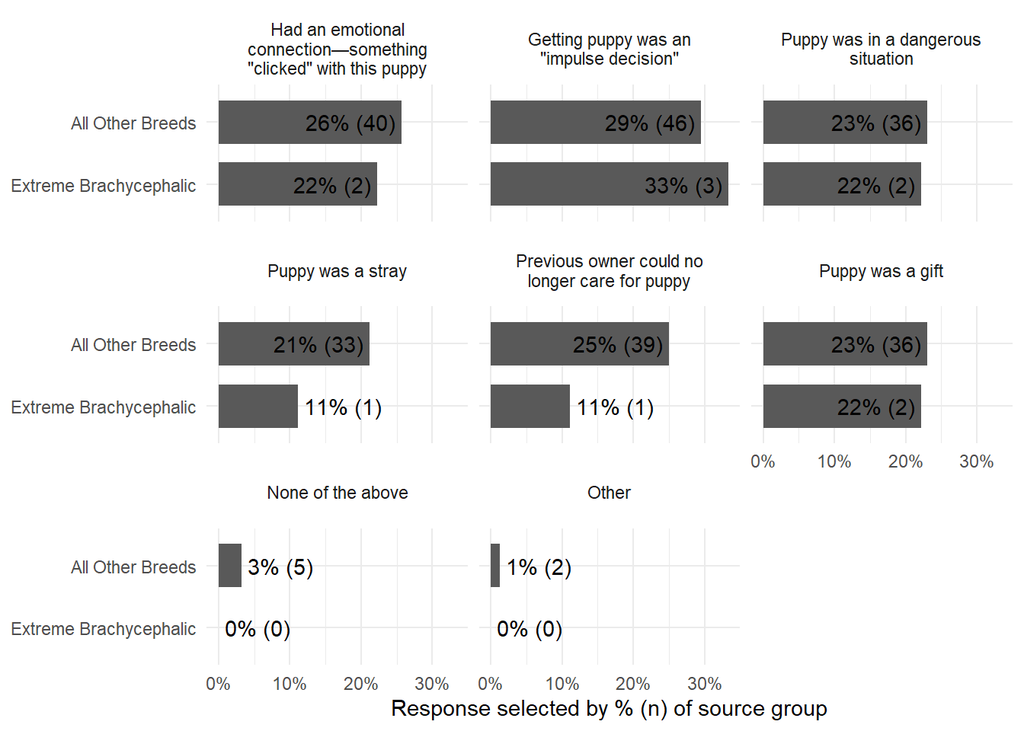

#### >> Q20

**Q20: How long was it from the time you started looking for a puppy to when you first brought your puppy home?**

1836 non-empty/NA responses out of 1836 possible responses ( 100 %)

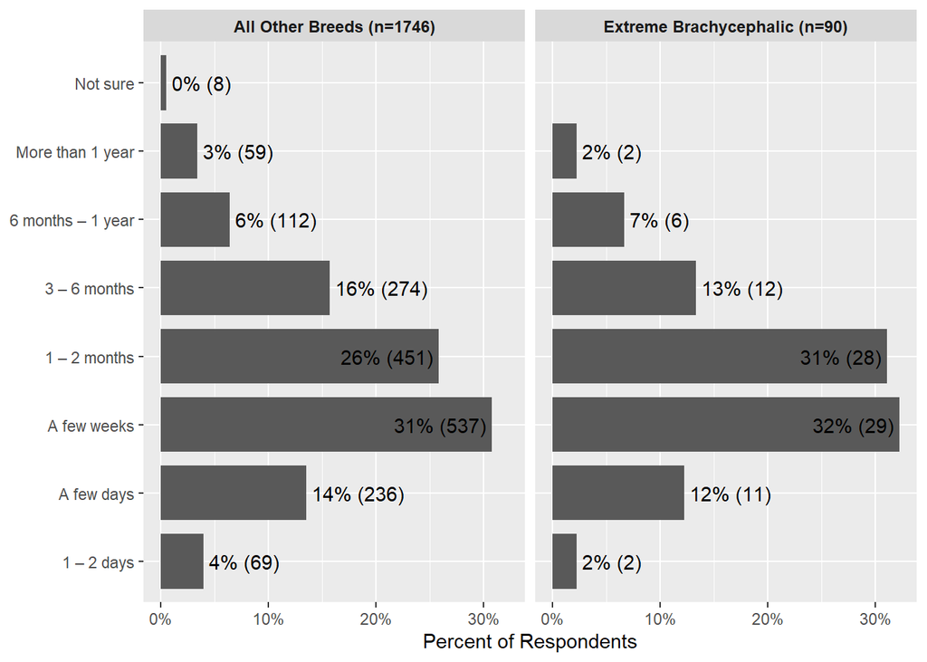

#### >> Q21 (…)

**Q21: How did this compare to the time you expected it would take?**

1836 non-empty/NA responses out of 1836 possible responses ( 100 %)

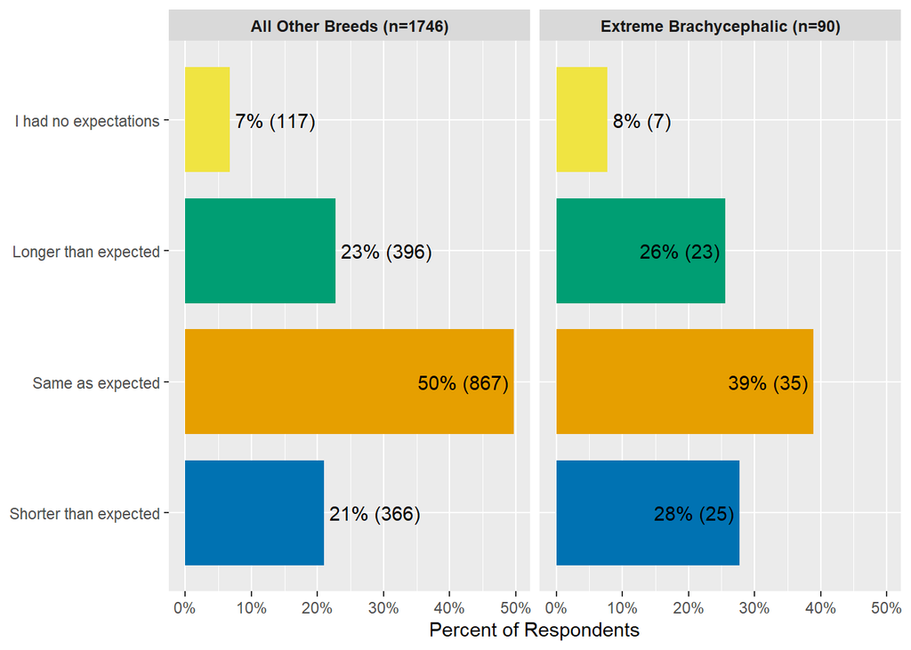

##### >>> Q22

**Why do you think it took as long as it did to get a puppy?**

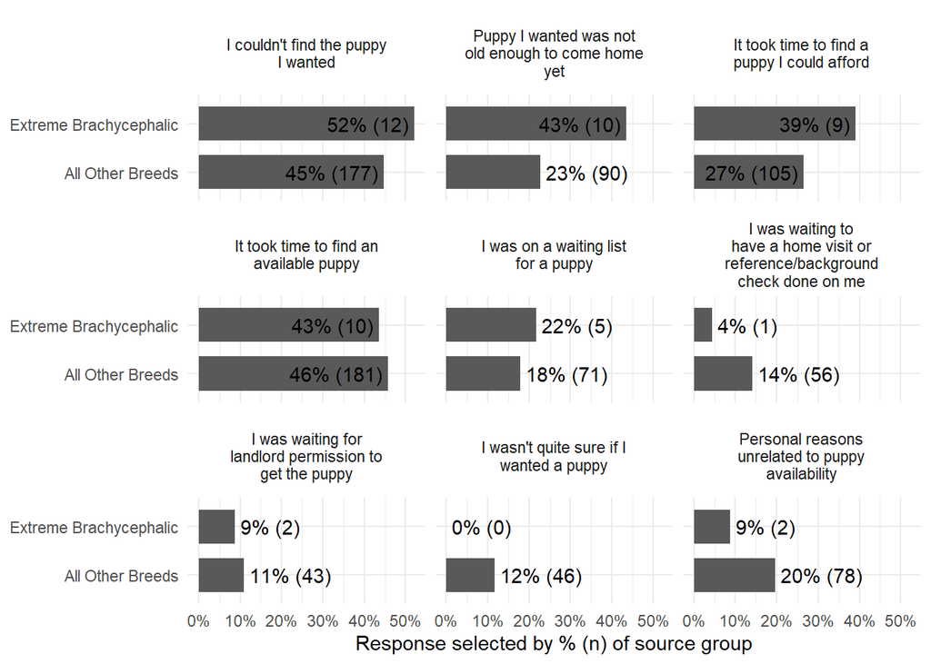

##### >>> Q23

**Why do you think you got your puppy faster than expected?**

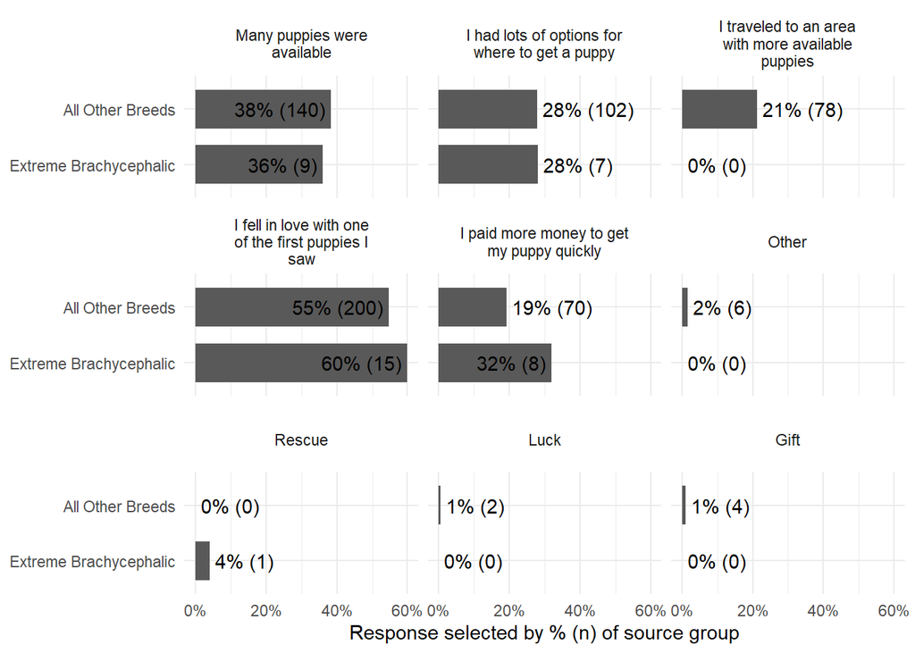

#### >> Motivation/Preferences for Puppy Features

#### >> Q24

**Q24: How closely did the puppy you got match what you were searching for?**

1896 non-empty/NA responses out of 1896 possible responses ( 100 %)

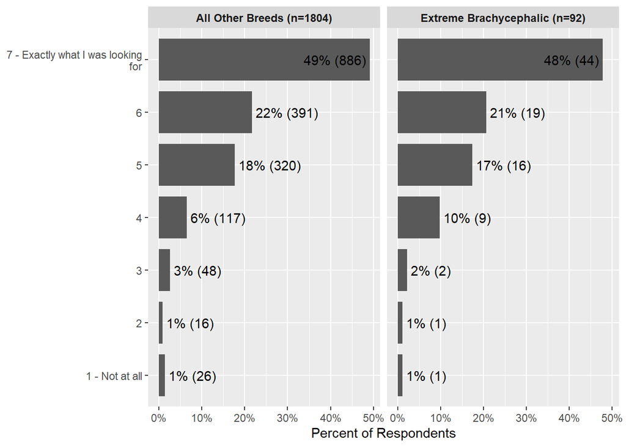

#### >> Q25 (…)

**How important were each of the following in choosing your puppy?**

1896 total non-empty/NA responses from 1896 possible respondents ( 100 %)

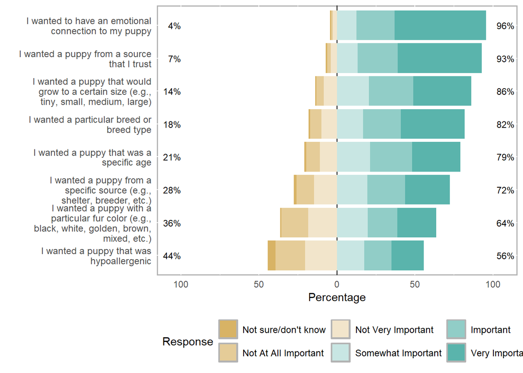

##### >>> Q25

**Q25r1: I wanted a puppy from a specific source (e.g., shelter, breeder, etc.) - How important were each of the following in choosing your puppy?**

1896 non-empty/NA responses out of 1896 possible responses ( 100 %)

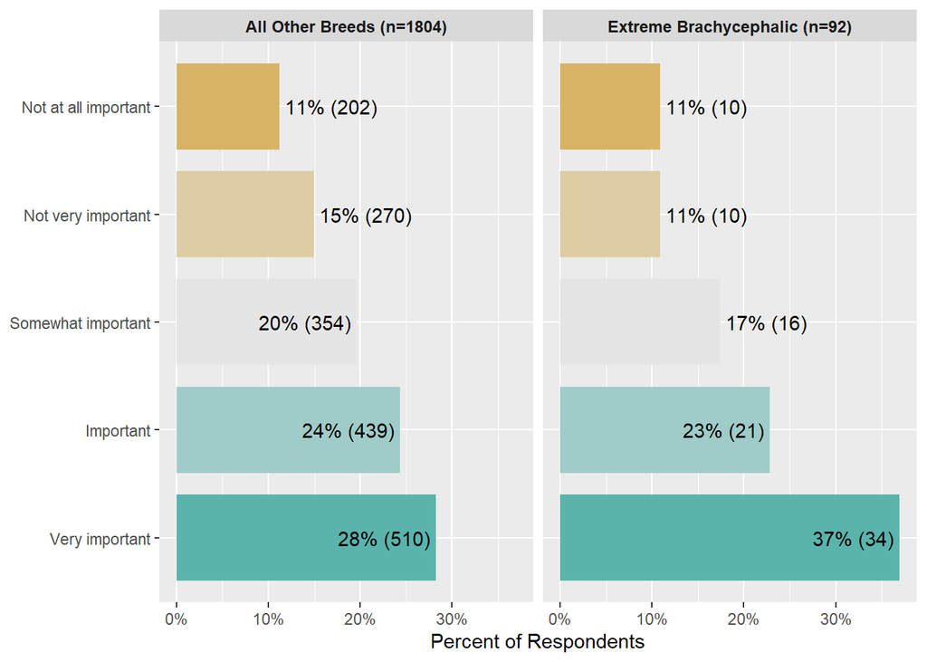

##### >>> Q25r2

**Q25r2: I wanted a puppy that was a specific age - How important were each of the following in choosing your puppy?**

1896 non-empty/NA responses out of 1896 possible responses ( 100 %)

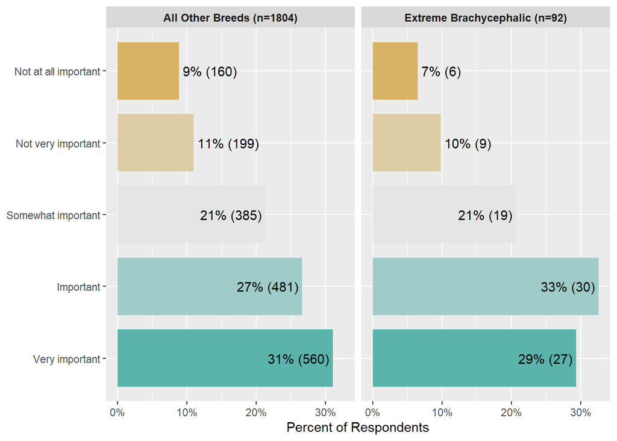

##### >>> Q25r3

**Q25r3: I wanted a puppy that would grow to a certain size (e.g., tiny, small, medium, large) - How important were each of the following in choosing your puppy?**

1896 non-empty/NA responses out of 1896 possible responses ( 100 %)

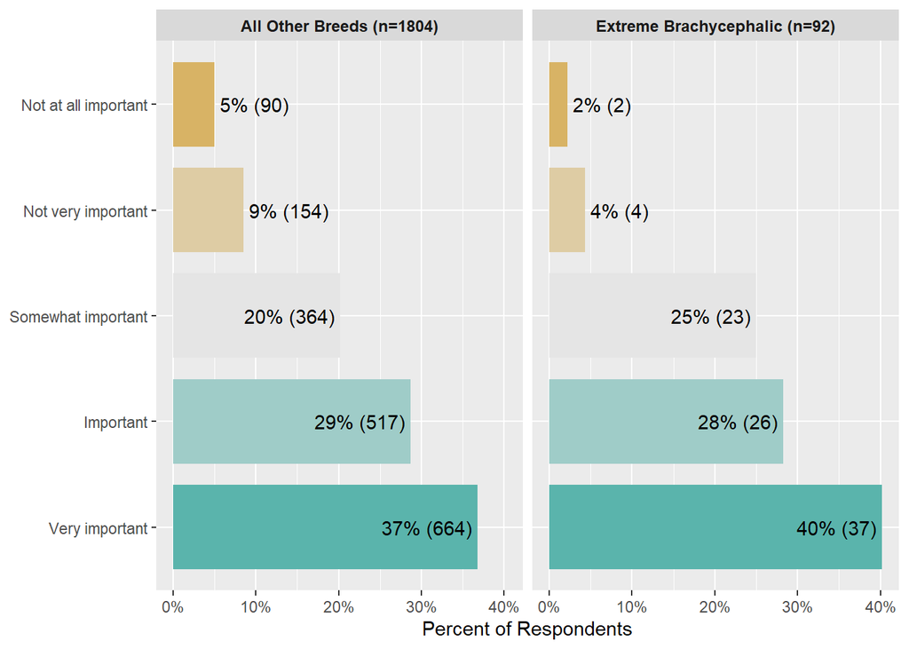

##### >>> Q25r4

**Q25r4: I wanted a particular breed or breed type - How important were each of the following in choosing your puppy?**

1896 non-empty/NA responses out of 1896 possible responses ( 100 %)

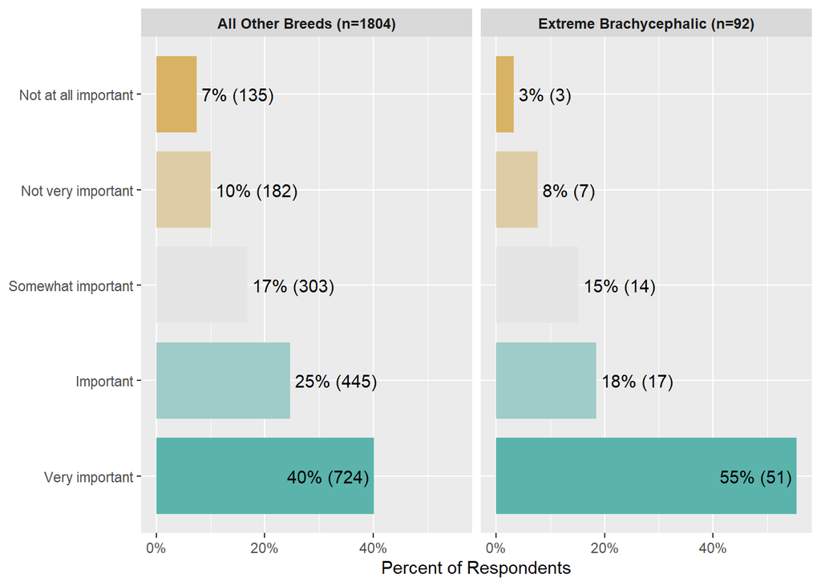

##### >>> Q25r5

**Q25r5: I wanted to have an emotional connection to my puppy - How important were each of the following in choosing your puppy?**

1896 non-empty/NA responses out of 1896 possible responses ( 100 %)

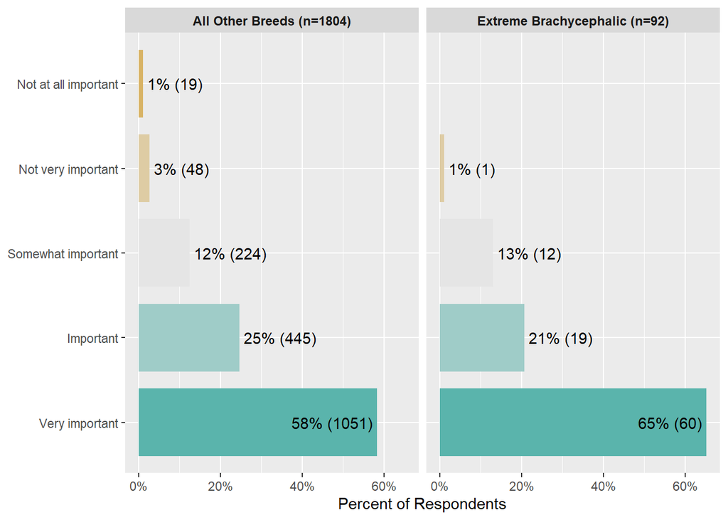